# Risk Factor Analysis

## Outcome Variable

**Outcome Variable:** stunted

## Predictor Variables

**Intervention Variable:** predfeed36

**Adjustment Set:**

unadjusted

## Stratifying Variables

The analysis was stratified on these variable(s):

- agecat
- studyid
- country

## Data Summary

| agecat | studyid | country | predfeed36 | stunted | n_cell | n | outcome_variable |
| --- | --- | --- | --- | --- | --- | --- | --- |
| Birth | ki0047075b-MAL-ED | BANGLADESH | 1 | 0 | 62 | 221 | stunted |
| Birth | ki0047075b-MAL-ED | BANGLADESH | 1 | 1 | 10 | 221 | stunted |
| Birth | ki0047075b-MAL-ED | BANGLADESH | 0 | 0 | 119 | 221 | stunted |
| Birth | ki0047075b-MAL-ED | BANGLADESH | 0 | 1 | 30 | 221 | stunted |
| Birth | ki0047075b-MAL-ED | BRAZIL | 1 | 0 | 6 | 65 | stunted |
| Birth | ki0047075b-MAL-ED | BRAZIL | 1 | 1 | 2 | 65 | stunted |
| Birth | ki0047075b-MAL-ED | BRAZIL | 0 | 0 | 50 | 65 | stunted |
| Birth | ki0047075b-MAL-ED | BRAZIL | 0 | 1 | 7 | 65 | stunted |
| Birth | ki0047075b-MAL-ED | INDIA | 1 | 0 | 2 | 42 | stunted |
| Birth | ki0047075b-MAL-ED | INDIA | 1 | 1 | 2 | 42 | stunted |
| Birth | ki0047075b-MAL-ED | INDIA | 0 | 0 | 31 | 42 | stunted |
| Birth | ki0047075b-MAL-ED | INDIA | 0 | 1 | 7 | 42 | stunted |
| Birth | ki0047075b-MAL-ED | NEPAL | 1 | 0 | 0 | 26 | stunted |
| Birth | ki0047075b-MAL-ED | NEPAL | 1 | 1 | 1 | 26 | stunted |
| Birth | ki0047075b-MAL-ED | NEPAL | 0 | 0 | 24 | 26 | stunted |
| Birth | ki0047075b-MAL-ED | NEPAL | 0 | 1 | 1 | 26 | stunted |
| Birth | ki0047075b-MAL-ED | PERU | 1 | 0 | 52 | 223 | stunted |
| Birth | ki0047075b-MAL-ED | PERU | 1 | 1 | 6 | 223 | stunted |
| Birth | ki0047075b-MAL-ED | PERU | 0 | 0 | 145 | 223 | stunted |
| Birth | ki0047075b-MAL-ED | PERU | 0 | 1 | 20 | 223 | stunted |
| Birth | ki0047075b-MAL-ED | SOUTH AFRICA | 1 | 0 | 2 | 105 | stunted |
| Birth | ki0047075b-MAL-ED | SOUTH AFRICA | 1 | 1 | 0 | 105 | stunted |
| Birth | ki0047075b-MAL-ED | SOUTH AFRICA | 0 | 0 | 94 | 105 | stunted |
| Birth | ki0047075b-MAL-ED | SOUTH AFRICA | 0 | 1 | 9 | 105 | stunted |
| Birth | ki0047075b-MAL-ED | TANZANIA, UNITED REPUBLIC OF | 1 | 0 | 0 | 119 | stunted |
| Birth | ki0047075b-MAL-ED | TANZANIA, UNITED REPUBLIC OF | 1 | 1 | 0 | 119 | stunted |
| Birth | ki0047075b-MAL-ED | TANZANIA, UNITED REPUBLIC OF | 0 | 0 | 98 | 119 | stunted |
| Birth | ki0047075b-MAL-ED | TANZANIA, UNITED REPUBLIC OF | 0 | 1 | 21 | 119 | stunted |
| Birth | ki1000109-EE | PAKISTAN | 1 | 0 | 2 | 7 | stunted |
| Birth | ki1000109-EE | PAKISTAN | 1 | 1 | 1 | 7 | stunted |

[output cut: 114 more lines]

The following strata were considered:

- agecat: 24 months, studyid: ki0047075b-MAL-ED, country: BANGLADESH
- agecat: 24 months, studyid: ki0047075b-MAL-ED, country: BRAZIL
- agecat: 24 months, studyid: ki0047075b-MAL-ED, country: INDIA
- agecat: 24 months, studyid: ki0047075b-MAL-ED, country: NEPAL
- agecat: 24 months, studyid: ki0047075b-MAL-ED, country: PERU
- agecat: 24 months, studyid: ki0047075b-MAL-ED, country: SOUTH AFRICA
- agecat: 24 months, studyid: ki0047075b-MAL-ED, country: TANZANIA, UNITED REPUBLIC OF
- agecat: 24 months, studyid: ki1000109-EE, country: PAKISTAN
- agecat: 24 months, studyid: ki1113344-GMS-Nepal, country: NEPAL
- agecat: 24 months, studyid: ki1148112-LCNI-5, country: MALAWI
- agecat: 24 months, studyid: kiGH5241-JiVitA-3, country: BANGLADESH
- agecat: 24 months, studyid: kiGH5241-JiVitA-4, country: BANGLADESH
- agecat: 6 months, studyid: ki0047075b-MAL-ED, country: BANGLADESH
- agecat: 6 months, studyid: ki0047075b-MAL-ED, country: BRAZIL
- agecat: 6 months, studyid: ki0047075b-MAL-ED, country: INDIA
- agecat: 6 months, studyid: ki0047075b-MAL-ED, country: NEPAL
- agecat: 6 months, studyid: ki0047075b-MAL-ED, country: PERU
- agecat: 6 months, studyid: ki0047075b-MAL-ED, country: SOUTH AFRICA
- agecat: 6 months, studyid: ki0047075b-MAL-ED, country: TANZANIA, UNITED REPUBLIC OF
- agecat: 6 months, studyid: ki1000109-EE, country: PAKISTAN
- agecat: 6 months, studyid: ki1000304b-SAS-FoodSuppl, country: INDIA
- agecat: 6 months, studyid: ki1113344-GMS-Nepal, country: NEPAL
- agecat: 6 months, studyid: ki1148112-LCNI-5, country: MALAWI
- agecat: 6 months, studyid: kiGH5241-JiVitA-3, country: BANGLADESH
- agecat: 6 months, studyid: kiGH5241-JiVitA-4, country: BANGLADESH
- agecat: Birth, studyid: ki0047075b-MAL-ED, country: BANGLADESH
- agecat: Birth, studyid: ki0047075b-MAL-ED, country: BRAZIL
- agecat: Birth, studyid: ki0047075b-MAL-ED, country: INDIA
- agecat: Birth, studyid: ki0047075b-MAL-ED, country: NEPAL
- agecat: Birth, studyid: ki0047075b-MAL-ED, country: PERU
- agecat: Birth, studyid: ki0047075b-MAL-ED, country: SOUTH AFRICA
- agecat: Birth, studyid: ki0047075b-MAL-ED, country: TANZANIA, UNITED REPUBLIC OF
- agecat: Birth, studyid: ki1000109-EE, country: PAKISTAN
- agecat: Birth, studyid: ki1113344-GMS-Nepal, country: NEPAL
- agecat: Birth, studyid: kiGH5241-JiVitA-3, country: BANGLADESH
- agecat: Birth, studyid: kiGH5241-JiVitA-4, country: BANGLADESH

### Dropped Strata

Some strata were dropped due to rare outcomes:

## Methods Detail

We’re interested in the causal parameters $E[Y_a]$ for all values of $a \in \mathcal{A}$. These parameters represent the mean outcome if, possibly contrary to fact, we intervened to set all units to have $A=a$. Under the randomization and positivity assumptions, these are identified by the statistical parameters $\psi_a=E_W[E_{Y|A,W}(Y|A=a,W)]$. In addition, we’re interested in the mean of $Y$, $E[Y]$ under no intervention (the observed mean). We will estimate these parameters by using SuperLearner to fit the relevant likelihood factors – $E_{Y|A,W}(Y|A=a,W)$ and $p(A=a|W)$, and then updating our likelihood fit using a joint TMLE.

For unadjusted analyses ($W=\{\}$), initial likelihoods were estimated using Lrnr_glm to estimate the simple $E(Y|A)$ and Lrnr_mean to estimate $p(A)$. For adjusted analyses, a small library containing Lrnr_glmnet, Lrnr_xgboost, and Lrnr_mean was used.

Having estimated these parameters, we will then use the delta method to estimate relative risks and attributable risks relative to a prespecified baseline level of $A$.

# Results Detail

## Results Plots

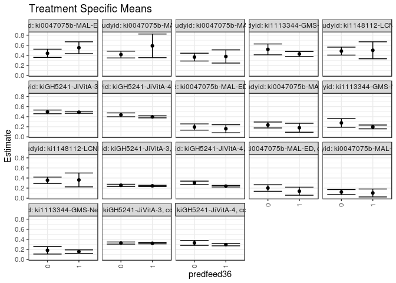

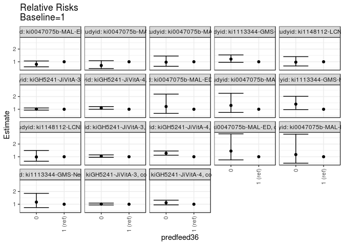

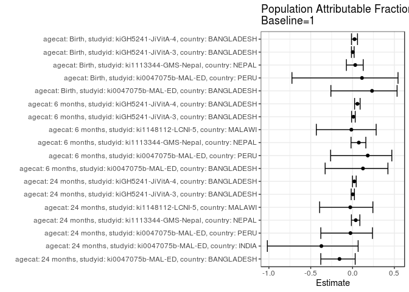

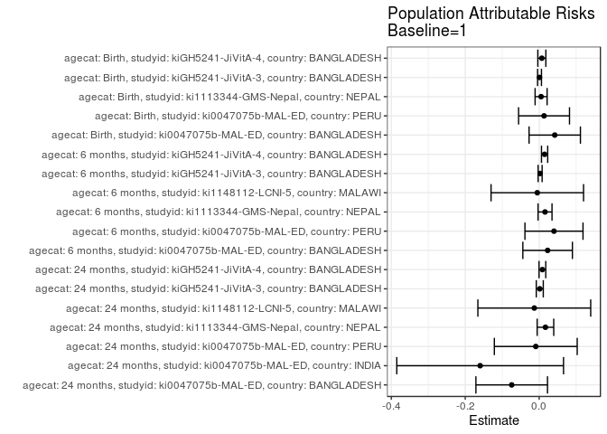

## Results Table

### Parameter: TSM

| agecat | studyid | country | intervention_level | baseline_level | estimate | ci_lower | ci_upper |
| --- | --- | --- | --- | --- | --- | --- | --- |
| Birth | ki0047075b-MAL-ED | BANGLADESH | 1 | NA | 0.1388889 | 0.0588262 | 0.2189515 |
| Birth | ki0047075b-MAL-ED | BANGLADESH | 0 | NA | 0.2013423 | 0.1368084 | 0.2658761 |
| Birth | ki0047075b-MAL-ED | PERU | 1 | NA | 0.1034483 | 0.0248959 | 0.1820007 |
| Birth | ki0047075b-MAL-ED | PERU | 0 | NA | 0.1212121 | 0.0713010 | 0.1711232 |
| Birth | ki1113344-GMS-Nepal | NEPAL | 1 | NA | 0.1563981 | 0.1217093 | 0.1910869 |
| Birth | ki1113344-GMS-Nepal | NEPAL | 0 | NA | 0.1826923 | 0.1083566 | 0.2570280 |
| Birth | kiGH5241-JiVitA-3 | BANGLADESH | 1 | NA | 0.3225342 | 0.3107922 | 0.3342762 |
| Birth | kiGH5241-JiVitA-3 | BANGLADESH | 0 | NA | 0.3268002 | 0.3057876 | 0.3478128 |
| Birth | kiGH5241-JiVitA-4 | BANGLADESH | 1 | NA | 0.2951476 | 0.2712760 | 0.3190192 |
| Birth | kiGH5241-JiVitA-4 | BANGLADESH | 0 | NA | 0.3301158 | 0.2815740 | 0.3786576 |
| 6 months | ki0047075b-MAL-ED | BANGLADESH | 1 | NA | 0.1604938 | 0.0803900 | 0.2405977 |
| 6 months | ki0047075b-MAL-ED | BANGLADESH | 0 | NA | 0.1949686 | 0.1332601 | 0.2566770 |
| 6 months | ki0047075b-MAL-ED | PERU | 1 | NA | 0.1805556 | 0.0915439 | 0.2695672 |
| 6 months | ki0047075b-MAL-ED | PERU | 0 | NA | 0.2350000 | 0.1761295 | 0.2938705 |
| 6 months | ki1113344-GMS-Nepal | NEPAL | 1 | NA | 0.1966825 | 0.1587221 | 0.2346429 |
| 6 months | ki1113344-GMS-Nepal | NEPAL | 0 | NA | 0.2761905 | 0.1905888 | 0.3617922 |
| 6 months | ki1148112-LCNI-5 | MALAWI | 1 | NA | 0.3617021 | 0.2240807 | 0.4993236 |
| 6 months | ki1148112-LCNI-5 | MALAWI | 0 | NA | 0.3555556 | 0.2928937 | 0.4182174 |
| 6 months | kiGH5241-JiVitA-3 | BANGLADESH | 1 | NA | 0.2446534 | 0.2328069 | 0.2564999 |
| 6 months | kiGH5241-JiVitA-3 | BANGLADESH | 0 | NA | 0.2557427 | 0.2347393 | 0.2767461 |
| 6 months | kiGH5241-JiVitA-4 | BANGLADESH | 1 | NA | 0.2379342 | 0.2217670 | 0.2541014 |
| 6 months | kiGH5241-JiVitA-4 | BANGLADESH | 0 | NA | 0.3036481 | 0.2688614 | 0.3384348 |
| 24 months | ki0047075b-MAL-ED | BANGLADESH | 1 | NA | 0.5507246 | 0.4330795 | 0.6683697 |
| 24 months | ki0047075b-MAL-ED | BANGLADESH | 0 | NA | 0.4405594 | 0.3589978 | 0.5221211 |
| 24 months | ki0047075b-MAL-ED | INDIA | 1 | NA | 0.5882353 | 0.3537610 | 0.8227096 |
| 24 months | ki0047075b-MAL-ED | INDIA | 0 | NA | 0.4154589 | 0.3481758 | 0.4827420 |
| 24 months | ki0047075b-MAL-ED | PERU | 1 | NA | 0.3773585 | 0.2465339 | 0.5081831 |
| 24 months | ki0047075b-MAL-ED | PERU | 0 | NA | 0.3648649 | 0.2871151 | 0.4426147 |
| 24 months | ki1113344-GMS-Nepal | NEPAL | 1 | NA | 0.4269972 | 0.3760556 | 0.4779389 |
| 24 months | ki1113344-GMS-Nepal | NEPAL | 0 | NA | 0.5180723 | 0.4104549 | 0.6256897 |
| 24 months | ki1148112-LCNI-5 | MALAWI | 1 | NA | 0.5000000 | 0.3314881 | 0.6685119 |
| 24 months | ki1148112-LCNI-5 | MALAWI | 0 | NA | 0.4838710 | 0.4049889 | 0.5627530 |
| 24 months | kiGH5241-JiVitA-3 | BANGLADESH | 1 | NA | 0.4880024 | 0.4676603 | 0.5083445 |
| 24 months | kiGH5241-JiVitA-3 | BANGLADESH | 0 | NA | 0.4950000 | 0.4584331 | 0.5315669 |
| 24 months | kiGH5241-JiVitA-4 | BANGLADESH | 1 | NA | 0.3965790 | 0.3764588 | 0.4166992 |
| 24 months | kiGH5241-JiVitA-4 | BANGLADESH | 0 | NA | 0.4360987 | 0.3972864 | 0.4749109 |

### Parameter: E(Y)

| agecat | studyid | country | intervention_level | baseline_level | estimate | ci_lower | ci_upper |
| --- | --- | --- | --- | --- | --- | --- | --- |
| Birth | ki0047075b-MAL-ED | BANGLADESH | NA | NA | 0.1809955 | 0.1301194 | 0.2318716 |
| Birth | ki0047075b-MAL-ED | PERU | NA | NA | 0.1165919 | 0.0743750 | 0.1588088 |
| Birth | ki1113344-GMS-Nepal | NEPAL | NA | NA | 0.1615970 | 0.1301114 | 0.1930825 |
| Birth | kiGH5241-JiVitA-3 | BANGLADESH | NA | NA | 0.3234716 | 0.3131402 | 0.3338029 |
| Birth | kiGH5241-JiVitA-4 | BANGLADESH | NA | NA | 0.3023441 | 0.2806174 | 0.3240708 |
| 6 months | ki0047075b-MAL-ED | BANGLADESH | NA | NA | 0.1833333 | 0.1342773 | 0.2323893 |
| 6 months | ki0047075b-MAL-ED | PERU | NA | NA | 0.2205882 | 0.1712211 | 0.2699554 |
| 6 months | ki1113344-GMS-Nepal | NEPAL | NA | NA | 0.2125237 | 0.1775632 | 0.2474842 |
| 6 months | ki1148112-LCNI-5 | MALAWI | NA | NA | 0.3566176 | 0.2995882 | 0.4136471 |
| 6 months | kiGH5241-JiVitA-3 | BANGLADESH | NA | NA | 0.2471936 | 0.2366536 | 0.2577336 |
| 6 months | kiGH5241-JiVitA-4 | BANGLADESH | NA | NA | 0.2525687 | 0.2374550 | 0.2676823 |
| 24 months | ki0047075b-MAL-ED | BANGLADESH | NA | NA | 0.4764151 | 0.4090254 | 0.5438047 |
| 24 months | ki0047075b-MAL-ED | INDIA | NA | NA | 0.4285714 | 0.3636201 | 0.4935228 |
| 24 months | ki0047075b-MAL-ED | PERU | NA | NA | 0.3681592 | 0.3013164 | 0.4350020 |
| 24 months | ki1113344-GMS-Nepal | NEPAL | NA | NA | 0.4439462 | 0.3977834 | 0.4901089 |
| 24 months | ki1148112-LCNI-5 | MALAWI | NA | NA | 0.4867725 | 0.4153250 | 0.5582200 |
| 24 months | kiGH5241-JiVitA-3 | BANGLADESH | NA | NA | 0.4896170 | 0.4715168 | 0.5077172 |
| 24 months | kiGH5241-JiVitA-4 | BANGLADESH | NA | NA | 0.4052853 | 0.3865623 | 0.4240082 |

### Parameter: RR

| agecat | studyid | country | intervention_level | baseline_level | estimate | ci_lower | ci_upper |
| --- | --- | --- | --- | --- | --- | --- | --- |
| Birth | ki0047075b-MAL-ED | BANGLADESH | 1 | 1 | 1.0000000 | 1.0000000 | 1.000000 |
| Birth | ki0047075b-MAL-ED | BANGLADESH | 0 | 1 | 1.4496644 | 0.7495860 | 2.803584 |
| Birth | ki0047075b-MAL-ED | PERU | 1 | 1 | 1.0000000 | 1.0000000 | 1.000000 |
| Birth | ki0047075b-MAL-ED | PERU | 0 | 1 | 1.1717172 | 0.4939463 | 2.779495 |
| Birth | ki1113344-GMS-Nepal | NEPAL | 1 | 1 | 1.0000000 | 1.0000000 | 1.000000 |
| Birth | ki1113344-GMS-Nepal | NEPAL | 0 | 1 | 1.1681235 | 0.7349028 | 1.856725 |
| Birth | kiGH5241-JiVitA-3 | BANGLADESH | 1 | 1 | 1.0000000 | 1.0000000 | 1.000000 |
| Birth | kiGH5241-JiVitA-3 | BANGLADESH | 0 | 1 | 1.0132264 | 0.9415873 | 1.090316 |
| Birth | kiGH5241-JiVitA-4 | BANGLADESH | 1 | 1 | 1.0000000 | 1.0000000 | 1.000000 |
| Birth | kiGH5241-JiVitA-4 | BANGLADESH | 0 | 1 | 1.1184772 | 0.9485832 | 1.318800 |
| 6 months | ki0047075b-MAL-ED | BANGLADESH | 1 | 1 | 1.0000000 | 1.0000000 | 1.000000 |
| 6 months | ki0047075b-MAL-ED | BANGLADESH | 0 | 1 | 1.2148041 | 0.6727239 | 2.193692 |
| 6 months | ki0047075b-MAL-ED | PERU | 1 | 1 | 1.0000000 | 1.0000000 | 1.000000 |
| 6 months | ki0047075b-MAL-ED | PERU | 0 | 1 | 1.3015385 | 0.7486836 | 2.262641 |
| 6 months | ki1113344-GMS-Nepal | NEPAL | 1 | 1 | 1.0000000 | 1.0000000 | 1.000000 |
| 6 months | ki1113344-GMS-Nepal | NEPAL | 0 | 1 | 1.4042456 | 0.9747072 | 2.023075 |
| 6 months | ki1148112-LCNI-5 | MALAWI | 1 | 1 | 1.0000000 | 1.0000000 | 1.000000 |
| 6 months | ki1148112-LCNI-5 | MALAWI | 0 | 1 | 0.9830065 | 0.6463228 | 1.495076 |
| 6 months | kiGH5241-JiVitA-3 | BANGLADESH | 1 | 1 | 1.0000000 | 1.0000000 | 1.000000 |
| 6 months | kiGH5241-JiVitA-3 | BANGLADESH | 0 | 1 | 1.0453266 | 0.9523432 | 1.147389 |
| 6 months | kiGH5241-JiVitA-4 | BANGLADESH | 1 | 1 | 1.0000000 | 1.0000000 | 1.000000 |
| 6 months | kiGH5241-JiVitA-4 | BANGLADESH | 0 | 1 | 1.2761850 | 1.1202448 | 1.453832 |
| 24 months | ki0047075b-MAL-ED | BANGLADESH | 1 | 1 | 1.0000000 | 1.0000000 | 1.000000 |
| 24 months | ki0047075b-MAL-ED | BANGLADESH | 0 | 1 | 0.7999632 | 0.6029823 | 1.061293 |
| 24 months | ki0047075b-MAL-ED | INDIA | 1 | 1 | 1.0000000 | 1.0000000 | 1.000000 |
| 24 months | ki0047075b-MAL-ED | INDIA | 0 | 1 | 0.7062802 | 0.4593272 | 1.086005 |
| 24 months | ki0047075b-MAL-ED | PERU | 1 | 1 | 1.0000000 | 1.0000000 | 1.000000 |
| 24 months | ki0047075b-MAL-ED | PERU | 0 | 1 | 0.9668919 | 0.6436457 | 1.452476 |
| 24 months | ki1113344-GMS-Nepal | NEPAL | 1 | 1 | 1.0000000 | 1.0000000 | 1.000000 |
| 24 months | ki1113344-GMS-Nepal | NEPAL | 0 | 1 | 1.2132919 | 0.9548405 | 1.541700 |
| 24 months | ki1148112-LCNI-5 | MALAWI | 1 | 1 | 1.0000000 | 1.0000000 | 1.000000 |
| 24 months | ki1148112-LCNI-5 | MALAWI | 0 | 1 | 0.9677419 | 0.6655301 | 1.407186 |
| 24 months | kiGH5241-JiVitA-3 | BANGLADESH | 1 | 1 | 1.0000000 | 1.0000000 | 1.000000 |
| 24 months | kiGH5241-JiVitA-3 | BANGLADESH | 0 | 1 | 1.0143393 | 0.9333624 | 1.102342 |
| 24 months | kiGH5241-JiVitA-4 | BANGLADESH | 1 | 1 | 1.0000000 | 1.0000000 | 1.000000 |
| 24 months | kiGH5241-JiVitA-4 | BANGLADESH | 0 | 1 | 1.0996513 | 0.9979640 | 1.211700 |

### Parameter: PAR

| agecat | studyid | country | intervention_level | baseline_level | estimate | ci_lower | ci_upper |
| --- | --- | --- | --- | --- | --- | --- | --- |
| Birth | ki0047075b-MAL-ED | BANGLADESH | 1 | NA | 0.0421066 | -0.0273321 | 0.1115453 |
| Birth | ki0047075b-MAL-ED | PERU | 1 | NA | 0.0131437 | -0.0557257 | 0.0820130 |
| Birth | ki1113344-GMS-Nepal | NEPAL | 1 | NA | 0.0051989 | -0.0110450 | 0.0214427 |
| Birth | kiGH5241-JiVitA-3 | BANGLADESH | 1 | NA | 0.0009374 | -0.0043092 | 0.0061840 |
| Birth | kiGH5241-JiVitA-4 | BANGLADESH | 1 | NA | 0.0071965 | -0.0036810 | 0.0180740 |
| 6 months | ki0047075b-MAL-ED | BANGLADESH | 1 | NA | 0.0228395 | -0.0441821 | 0.0898611 |
| 6 months | ki0047075b-MAL-ED | PERU | 1 | NA | 0.0400327 | -0.0384888 | 0.1185541 |
| 6 months | ki1113344-GMS-Nepal | NEPAL | 1 | NA | 0.0158413 | -0.0030122 | 0.0346947 |
| 6 months | ki1148112-LCNI-5 | MALAWI | 1 | NA | -0.0050845 | -0.1301713 | 0.1200023 |
| 6 months | kiGH5241-JiVitA-3 | BANGLADESH | 1 | NA | 0.0025402 | -0.0028575 | 0.0079379 |
| 6 months | kiGH5241-JiVitA-4 | BANGLADESH | 1 | NA | 0.0146345 | 0.0062350 | 0.0230339 |
| 24 months | ki0047075b-MAL-ED | BANGLADESH | 1 | NA | -0.0743095 | -0.1711209 | 0.0225018 |
| 24 months | ki0047075b-MAL-ED | INDIA | 1 | NA | -0.1596639 | -0.3851677 | 0.0658400 |
| 24 months | ki0047075b-MAL-ED | PERU | 1 | NA | -0.0091993 | -0.1212581 | 0.1028595 |
| 24 months | ki1113344-GMS-Nepal | NEPAL | 1 | NA | 0.0169489 | -0.0054524 | 0.0393502 |
| 24 months | ki1148112-LCNI-5 | MALAWI | 1 | NA | -0.0132275 | -0.1658197 | 0.1393646 |
| 24 months | kiGH5241-JiVitA-3 | BANGLADESH | 1 | NA | 0.0016146 | -0.0078522 | 0.0110813 |
| 24 months | kiGH5241-JiVitA-4 | BANGLADESH | 1 | NA | 0.0087062 | -0.0003735 | 0.0177860 |

### Parameter: PAF

| agecat | studyid | country | intervention_level | baseline_level | estimate | ci_lower | ci_upper |
| --- | --- | --- | --- | --- | --- | --- | --- |
| Birth | ki0047075b-MAL-ED | BANGLADESH | 1 | NA | 0.2326389 | -0.2590259 | 0.5323027 |
| Birth | ki0047075b-MAL-ED | PERU | 1 | NA | 0.1127321 | -0.7244540 | 0.5434820 |
| Birth | ki1113344-GMS-Nepal | NEPAL | 1 | NA | 0.0321717 | -0.0736184 | 0.1275377 |
| Birth | kiGH5241-JiVitA-3 | BANGLADESH | 1 | NA | 0.0028979 | -0.0134577 | 0.0189896 |
| Birth | kiGH5241-JiVitA-4 | BANGLADESH | 1 | NA | 0.0238023 | -0.0128112 | 0.0590922 |
| 6 months | ki0047075b-MAL-ED | BANGLADESH | 1 | NA | 0.1245791 | -0.3277564 | 0.4228145 |
| 6 months | ki0047075b-MAL-ED | PERU | 1 | NA | 0.1814815 | -0.2625165 | 0.4693356 |
| 6 months | ki1113344-GMS-Nepal | NEPAL | 1 | NA | 0.0745388 | -0.0180969 | 0.1587456 |
| 6 months | ki1148112-LCNI-5 | MALAWI | 1 | NA | -0.0142575 | -0.4333092 | 0.2822775 |
| 6 months | kiGH5241-JiVitA-3 | BANGLADESH | 1 | NA | 0.0102762 | -0.0118072 | 0.0318777 |
| 6 months | kiGH5241-JiVitA-4 | BANGLADESH | 1 | NA | 0.0579426 | 0.0244388 | 0.0902958 |
| 24 months | ki0047075b-MAL-ED | BANGLADESH | 1 | NA | -0.1559765 | -0.3797113 | 0.0314774 |
| 24 months | ki0047075b-MAL-ED | INDIA | 1 | NA | -0.3725490 | -1.0185025 | 0.0666889 |
| 24 months | ki0047075b-MAL-ED | PERU | 1 | NA | -0.0249873 | -0.3793914 | 0.2383606 |
| 24 months | ki1113344-GMS-Nepal | NEPAL | 1 | NA | 0.0381779 | -0.0137168 | 0.0874160 |
| 24 months | ki1148112-LCNI-5 | MALAWI | 1 | NA | -0.0271739 | -0.3937793 | 0.2430034 |
| 24 months | kiGH5241-JiVitA-3 | BANGLADESH | 1 | NA | 0.0032976 | -0.0162252 | 0.0224455 |
| 24 months | kiGH5241-JiVitA-4 | BANGLADESH | 1 | NA | 0.0214817 | -0.0011183 | 0.0435716 |